# STA108 Project - A Case Study of the Effect of Pollution on Mortality

Chris Cheng, Richard Takiar, Truc Le

8/1/2019

Our data observe how the rate of mortality in a city responds to the variables such as annual precipitation, education level, percentage of nonwhite individuals, percentage of poor people, pollution of nitrogen oxides, and sulphur dioxide. Our goal of the analysis is to fit a regression model that best represents the trends of the data.

### **Preliminary Data Summary**

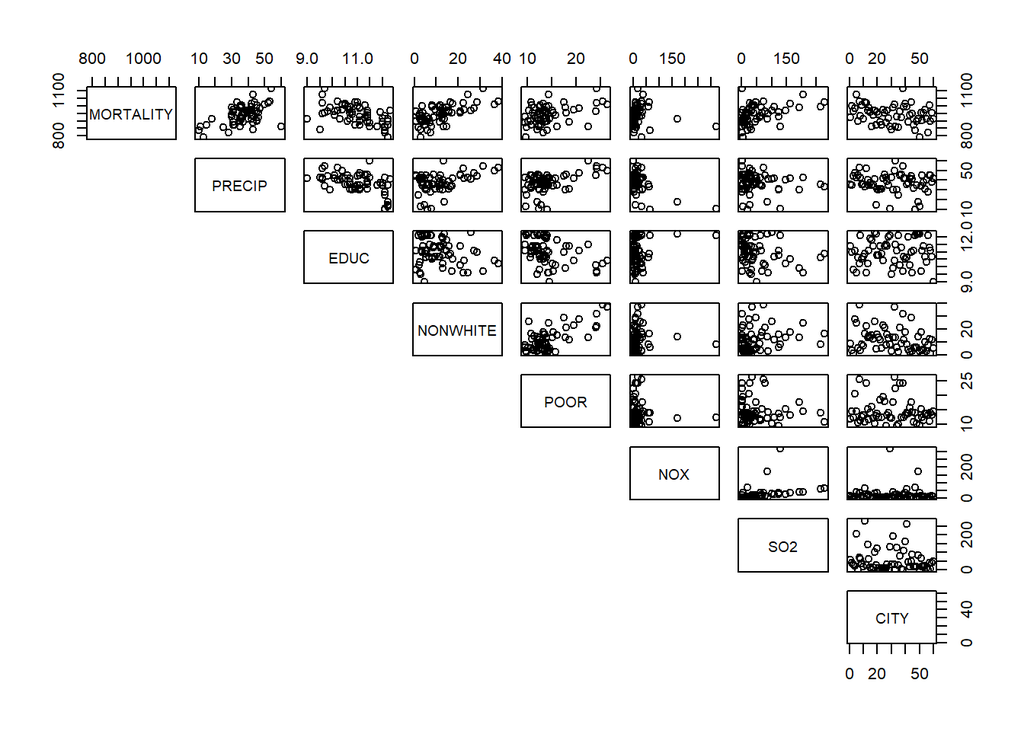

```r
# import the dataset
Mortality <- read.csv("/Users/LenovoUser/Downloads/mortality.csv")
View(Mortality)

# reorder the response variable (Y) to the first column
Mortality <- select(Mortality, MORTALITY, everything())

# obtain the matrix plot of the untransformed dataset
#pdf(file="Rplot2.pdf", paper = "a4r", width = 40)
plot(Mortality, lower.panel=NULL)
```

```r
#dev.off()
```

Summary of Transformed Data:

| Predictor | Estimate | Std. Error | t value | Pr(> |
| --- | --- | --- | --- | --- |
| (Intercept) | 980.475 | 141.9266 | 6.908 | 6.33E-09 |
| PRECIP | 2.3748 | 0.6709 | 3.54 | 0.000844 |
| EDUC | -19.1004 | 7.6787 | -2.487 | 0.016048 |
| NONWHITE | 49.9051 | 11.3256 | 4.406 | 5.15E-05 |
| POOR | -31.0975 | 34.5908 | -0.899 | 0.372713 |
| NOX | 10.1044 | 7.1973 | 1.404 | 0.166178 |
| SO2 | 8.0315 | 5.6263 | 1.427 | 0.159305 |

ANOVA Table of Transformed Data:

| Predictor | df | SS | MS | F value | P-val |
| --- | --- | --- | --- | --- | --- |
| PRECIP | 1 | 59256 | 59256 | 45.6291 | 1.12E-08 |
| EDUC | 1 | 20492 | 20492 | 15.78 | 0.0002161 |
| NONWHITE | 1 | 51678 | 51678 | 39.794 | 5.83E-08 |
| POOR | 1 | 7391 | 7391 | 5.6911 | 0.0206571 |
| NOX | 1 | 17982 | 17982 | 13.8469 | 0.0004808 |
| SO2 | 1 | 2646 | 2646 | 2.0377 | 0.1593045 |
| Residuals | 53 | 68828 | 1299 | - | - |

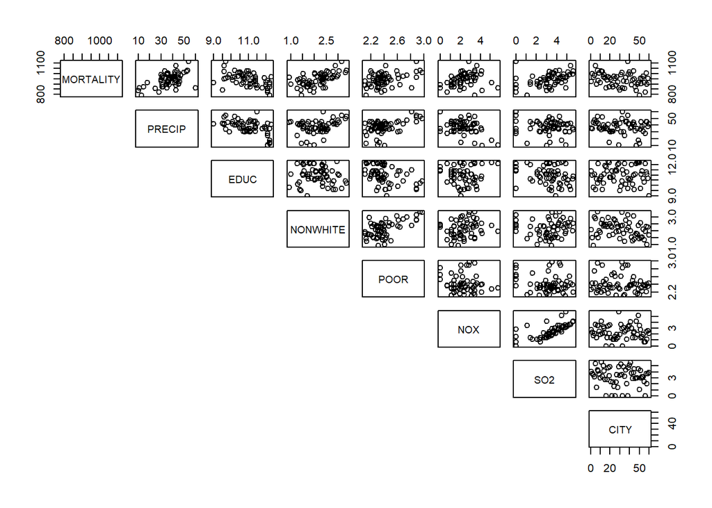

```r
# transform the X variables NOx and SO2 with natural log
# transform the X variables NONWHITE and POOR with cube root
Mortality.trans <- mutate(Mortality, NOX = log(NOX), SO2 = log(SO2),
                         NONWHITE = NONWHITE^(1/3), POOR = POOR^(1/3))

# re-plot the matrix plot of the transformed dataset
#pdf(file="Rplot_trans.pdf", paper = "a4r", width = 40)
plot(Mortality.trans, lower.panel=NULL)
```

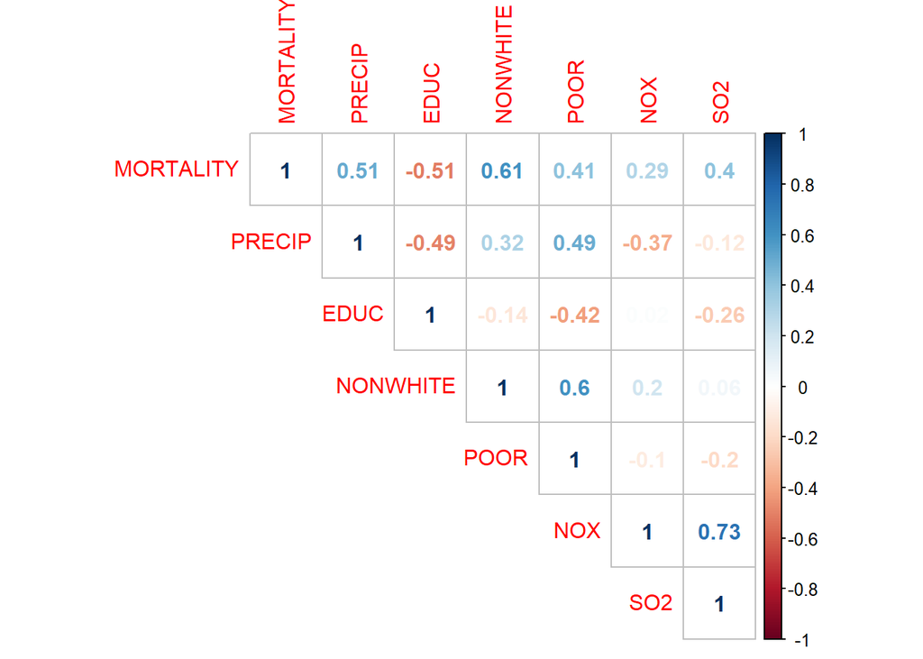

```r
#dev.off()

Mortality.corr <- Mortality.trans[,-8]
M <- cor(Mortality.corr)
corrplot(M, method="number", type="upper")
```

```r
full.model <- lm(MORTALITY~., data=Mortality.corr); full.model
```

```
##
## Call:
## lm(formula = MORTALITY ~ ., data = Mortality.corr)
##
## Coefficients:
## (Intercept)       PRECIP         EDUC     NONWHITE         POOR
##     980.475        2.375      -19.100       49.905      -31.098
##         NOX          SO2
##      10.104        8.031
```

```r
null.model <- lm(MORTALITY~1, data=Mortality.corr); null.model
```

```
##
## Call:
## lm(formula = MORTALITY ~ 1, data = Mortality.corr)
##
## Coefficients:
## (Intercept)
##       940.4
```

```r
xtable(anova(null.model, full.model))
```

|  | Res.Df | RSS | Df | Sum of Sq | F | Pr(>F) |
| --- | --- | --- | --- | --- | --- | --- |
| 1 | 59 | 228273.09 | NA | NA | NA | NA |
| 2 | 53 | 68827.78 | 6 | 159445.3 | 20.46316 | 3.138886e-12 |

```r
xtable(summary(full.model))
```

|  | Estimate | Std. Error | t value | Pr(>\|t\|) |
| --- | --- | --- | --- | --- |
| (Intercept) | 980.474972 | 141.9265678 | 6.9083258 | 6.334996e-09 |
| PRECIP | 2.374810 | 0.6709291 | 3.5395836 | 8.436541e-04 |
| EDUC | -19.100356 | 7.6787002 | -2.4874465 | 1.604768e-02 |
| NONWHITE | 49.905080 | 11.3255968 | 4.4063974 | 5.149811e-05 |
| POOR | -31.097512 | 34.5908125 | -0.8990107 | 3.727133e-01 |
| NOX | 10.104356 | 7.1972959 | 1.4039101 | 1.661783e-01 |
| SO2 | 8.031461 | 5.6262835 | 1.4274896 | 1.593045e-01 |

#### Full Regression Model Estimated Beta Coefficients (Rounded to 4 decimal points)

The regression model fit here is as follows:
$$\LARGE Y_i=\beta_0+\beta_1X_1+\beta_2X_2+\beta_3X_3+\beta_4X_4+\beta_5X_5+\beta_6X_6+\varepsilon$$

| Intercept | PRECIP | EDUC | NONWHITE | POOR | NOX | SO2 |
| --- | --- | --- | --- | --- | --- | --- |
| 980.475 | 2.375 | -19.100 | 49.905 | -31.098 | 10.104 | 8.031 |

The estimated regression formation equation is therefore as follows:
$$\large \hat{Y} = 980.475+2.375X_1-19.100X_2+49.905X_3-31.098X_4+10.104X_5+8.031X_6$$

### **Model Diagnostics**

[figure not shown]

```r
# plot Y values against fitted Y-values
p.orig.1 <- ggplot(Mortality.corr, aes(x=Mortality.corr$MORTALITY,
                           y=full.model$fitted.values)) +
  geom_point() + xlab("Fitted Mortality\n (in deaths per 100,000 people)") +
  ylab("Observed Mortality\n (in deaths per 100,000 people)") +
  ggtitle("Y values against fitted Y values")

# plot residuals against fitted Y-values
p.orig.2 <- ggplot(Mortality.corr, aes(x=full.model$fitted.values,
                           y=full.model$residuals)) + geom_point() +
  xlab("Fitted Mortality\n (in deaths per 100,000 people)") +
  ylab("Residuals of Observed Mortality\n (in deaths per 100,000 people)") +
  ggtitle("Residuals against fitted Y values")

# plot residuals against independent variables
p.orig.3 <- ggplot(Mortality.corr, aes(x=Mortality.corr$PRECIP,
                           y=full.model$residuals)) + geom_point() +
  xlab("Mean Annual Precipitation (in inches)") +
  ylab("Residuals of Observed Mortality\n (in deaths per 100,000 people)") +
  ggtitle("Residuals against Mean\n Annual Precipitation")

p.orig.4 <- ggplot(Mortality.corr, aes(x=Mortality.corr$EDUC,
                           y=full.model$residuals)) + geom_point() +
  xlab("Median Number school years completed\n by persons age 25 or over") +
  ylab("Residuals of Observed Mortality\n (in deaths per 100,000 people)") +
  ggtitle("Residuals against Median Number\n School Years completed by\n Persons 25 or older")

p.orig.5 <- ggplot(Mortality.corr, aes(x=Mortality.corr$NONWHITE,
                           y=full.model$residuals)) + geom_point() +
  xlab("Percentage of Population that\n is Nonwhite (in 1960)") +
  ylab("Residuals of Observed Mortality\n (in deaths per 100,000 people)") +
  ggtitle("Residuals against Nonwhite\n Population Proportion")

p.orig.6 <- ggplot(Mortality.corr, aes(x=Mortality.corr$POOR,
                           y=full.model$residuals)) + geom_point() +
  xlab("Percentage of households with\n annual income below $3000 (in 1960)") +
  ylab("Residuals of Observed Mortality\n (in deaths per 100,000 people)") +
  ggtitle("Residuals against Proportion of\n Households with under $3000\n annual income")

p.orig.7 <- ggplot(Mortality.corr, aes(x=Mortality.corr$NOX,
                           y=full.model$residuals)) + geom_point() +
  xlab("Relative Pollution Potential\n of Nitrogen Oxides") +
  ylab("Residuals of Observed Mortality\n (in deaths per 100,000 people)") +
  ggtitle("Residuals against Relative\n Pollution Potential of\n Nitrogen Oxides")

p.orig.8 <- ggplot(Mortality.corr, aes(x=Mortality.corr$SO2,
                           y=full.model$residuals)) + geom_point() +
  xlab("Relative Pollution Potential of\n Sulphur Dioxide") +
  ylab("Residuals of Observed Mortality\n (in deaths per 100,000 people)") +
  ggtitle("Residuals against Relative\n Pollution Potential of\n Sulphur Dioxide")

# plot histogram of residuals
p.orig.9 <- ggplot(Mortality.corr, aes(x=full.model$residuals)) +
  geom_histogram(binwidth = 10) +
  ggtitle("Histogram of Residuals of Mortality") +
  xlab("Residuals (in deaths per 100,000 population)")


grid.arrange(p.orig.1, p.orig.2, ncol=2)
```

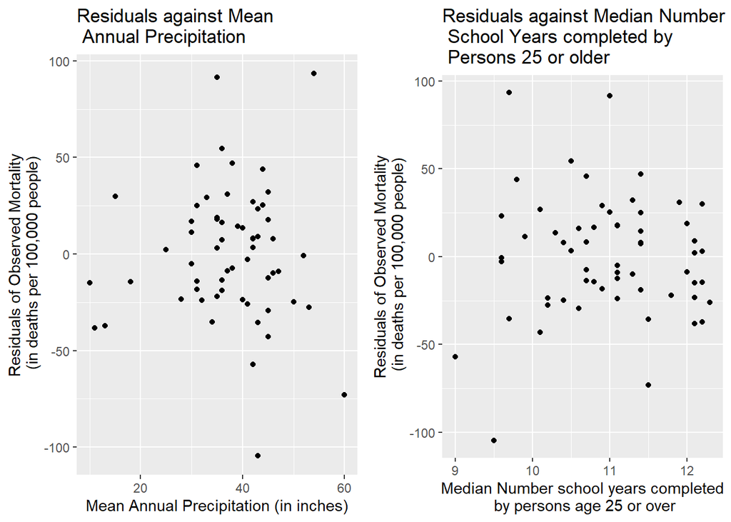

```r
grid.arrange(p.orig.3, p.orig.4, ncol=2)
```

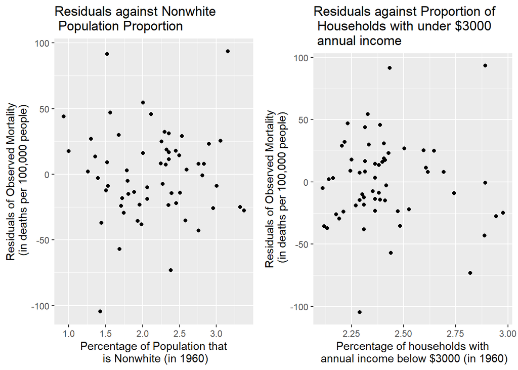

```r
grid.arrange(p.orig.5, p.orig.6, ncol=2)
```

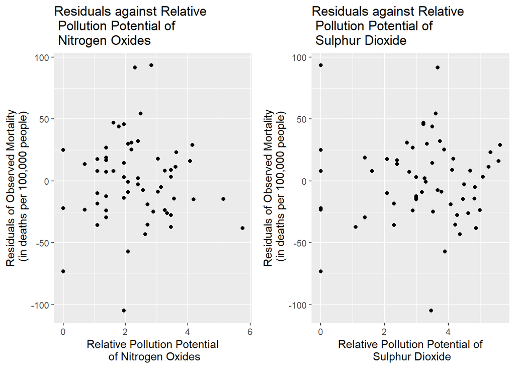

```r
grid.arrange(p.orig.7, p.orig.8, ncol=2)
```

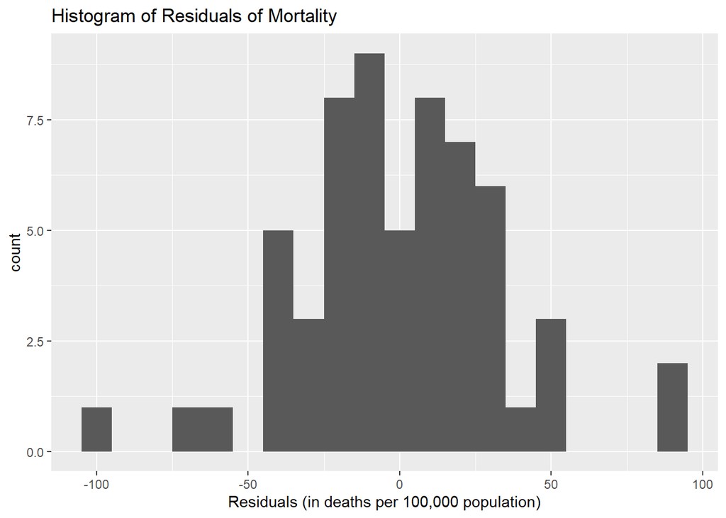

```r
grid.arrange(p.orig.9, ncol=1)
```

#### QQplot of the residuals

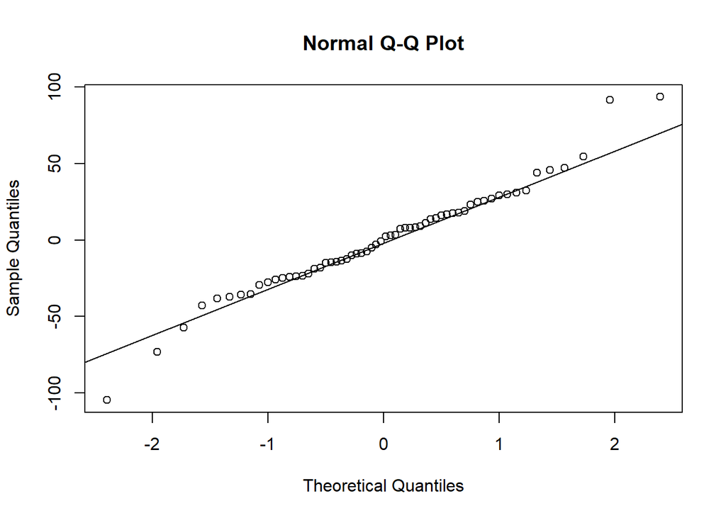

```r
qqnorm(full.model$residuals)
qqline(full.model$residuals)
```

### NONWHITE Data Non-linear Transformation

We believe that the matrix plot of Mortality (Y) vs. NONWHITE (X) appears to look nonlinear and may be better fitted with a polynomial regression model.

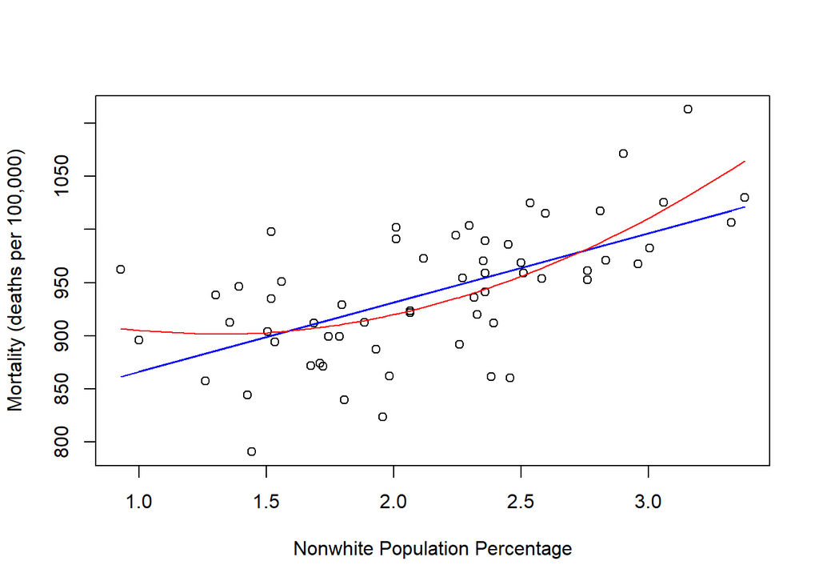

```r
y <- Mortality.corr$MORTALITY
X <- Mortality.corr$NONWHITE
x <- X - mean(X)
x2 <- x^2

fit.nonw <- lm(MORTALITY~Mortality.corr$NONWHITE, data=Mortality.corr)
fit.nonw.poly <- lm(y~x+x2)

plot(Mortality.corr$NONWHITE, Mortality.corr$MORTALITY,
     ylab='Mortality (deaths per 100,000)',
     xlab='Nonwhite Population Percentage', main='')
points(X, fit.nonw$fitted.values, type='l', col='blue')
points(X[order(x)], fit.nonw.poly$fitted.values[order(x)], type='l', col='red')
```

### SO2 Data Non-Linear Transformation

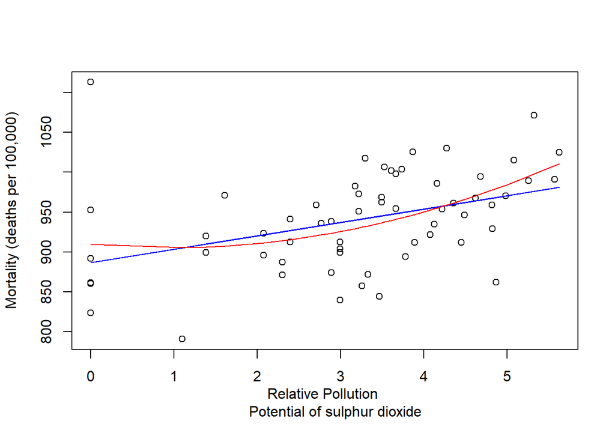

```r
y <- Mortality.corr$MORTALITY
X1 <- Mortality.corr$SO2
x1 <- X1 - mean(X1)
x2.1 <- (x1)^2

fit.SO2 <- lm(MORTALITY~Mortality.corr$SO2, data=Mortality.corr)
fit.SO2.poly <- lm(y~x1+x2.1)

plot(Mortality.corr$SO2, Mortality.corr$MORTALITY,
     ylab='Mortality (deaths per 100,000)', xlab='Relative Pollution
     Potential of sulphur dioxide', main='')
points(X1, fit.SO2$fitted.values, type='l', col='blue')
points(X1[order(x1)], fit.SO2.poly$fitted.values[order(x1)], type='l', col='red')
```

### Fit New Model with Nonlinear Terms

$\ Y = 1156.7132 \ + 2.1021X_1 \ -19.2041X_2 \ + 53.9390X_3 \ + 15.4809X_3^2 \ -44.7977X_4 \ + 7.7489X_5 \ + 9.0978X_6 \ + 0.3558X_6^2 \ + \epsilon$

```r
new.model <- lm(MORTALITY ~ PRECIP+EDUC+x+x2+POOR+NOX+x1+x2.1, data=Mortality.corr)
xtable(summary(new.model))
```

|  | Estimate | Std. Error | t value | Pr(>\|t\|) |
| --- | --- | --- | --- | --- |
| (Intercept) | 1156.7132585 | 153.929781 | 7.5145514 | 8.394877e-10 |
| PRECIP | 2.1021126 | 0.733639 | 2.8653229 | 6.036969e-03 |
| EDUC | -19.2041169 | 7.827199 | -2.4535107 | 1.760381e-02 |
| x | 53.9390625 | 12.379564 | 4.3571052 | 6.383001e-05 |
| x2 | 15.4809810 | 15.862289 | 0.9759613 | 3.336904e-01 |
| POOR | -44.7977227 | 37.622600 | -1.1907131 | 2.392789e-01 |
| NOX | 7.7489975 | 8.099578 | 0.9567162 | 3.432239e-01 |
| x1 | 9.0978030 | 6.963763 | 1.3064493 | 1.972610e-01 |
| x2.1 | 0.3558922 | 2.106389 | 0.1689584 | 8.664977e-01 |

```r
xtable(anova(new.model))
```

|  | Df | Sum Sq | Mean Sq | F value | Pr(>F) |
| --- | --- | --- | --- | --- | --- |
| PRECIP | 1 | 59255.70393 | 59255.70393 | 44.73764836 | 1.689499e-08 |
| EDUC | 1 | 20492.49695 | 20492.49695 | 15.47169407 | 2.538366e-04 |
| x | 1 | 51678.01220 | 51678.01220 | 39.01654329 | 8.418643e-08 |
| x2 | 1 | 1186.49721 | 1186.49721 | 0.89579722 | 3.483741e-01 |
| POOR | 1 | 11140.78599 | 11140.78599 | 8.41121669 | 5.489910e-03 |
| NOX | 1 | 14036.84936 | 14036.84936 | 10.59772459 | 2.014457e-03 |
| x1 | 1 | 2894.65270 | 2894.65270 | 2.18544285 | 1.454709e-01 |
| x2.1 | 1 | 37.81087 | 37.81087 | 0.02854695 | 8.664977e-01 |
| Residuals | 51 | 67550.28507 | 1324.51539 | NA | NA |

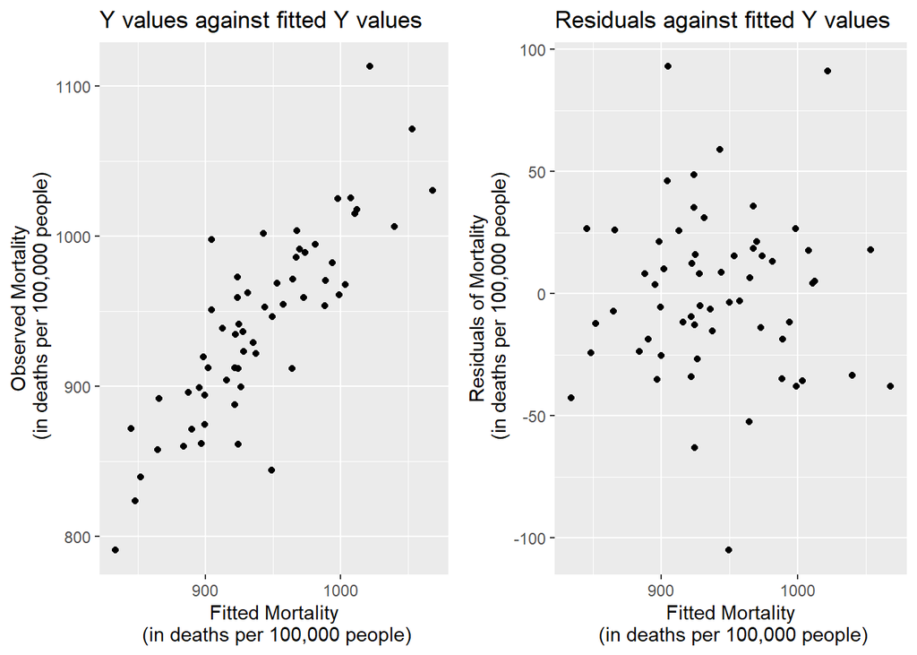

```r
# plot of observed Y values vs. fitted Y values
p.1 <- ggplot(new.model, aes(x=new.model$fitted.values,
                           y=Mortality.corr$MORTALITY)) +
  geom_point() + ggtitle("Y values against fitted Y values") +
  xlab("Fitted Mortality\n (in deaths per 100,000 people)") +
  ylab("Observed Mortality\n (in deaths per 100,000 people)")

# plot of residuals vs. fitted Y values
p.2 <- ggplot(new.model, aes(x=new.model$fitted.values,
                           y=new.model$residuals)) +
  geom_point() + ggtitle("Residuals against fitted Y values") +
  xlab("Fitted Mortality\n (in deaths per 100,000 people)") +
  ylab("Residuals of Mortality\n (in deaths per 100,000 people)")

# plot of residuals vs. predictor variables
p.3 <- ggplot(new.model, aes(x=Mortality.corr$PRECIP,
                           y=new.model$residuals)) + geom_point() +
  xlab("Mean Annual Precipitation\n (in inches))") +
  ylab("Residuals of Observed Mortality\n (in deaths per 100,000 people)") +
  ggtitle("Residuals against\n Mean Annual Precipitation")

p.4 <- ggplot(new.model, aes(x=Mortality.corr$EDUC,
                           y=new.model$residuals)) + geom_point() +
  xlab("Median Number school years completed\n by persons age 25 or over") +
  ylab("Residuals of Observed Mortality\n (in deaths per 100,000 people)") +
  ggtitle("Residuals against Median Number\n School Years completed by\n Persons 25
or older")

p.5 <- ggplot(new.model, aes(x=Mortality.corr$NONWHITE,
                           y=new.model$residuals)) + geom_point() +
  xlab("Percentage of Population\n that is Nonwhite (in 1960)") +
  ylab("Residuals of Observed Mortality\n (in deaths per 100,000 people)") +
  ggtitle("Residuals against Nonwhite\n Population Proportion")

p.6 <- ggplot(Mortality.corr, aes(x=Mortality.corr$NOX,
                           y=new.model$residuals)) + geom_point() +
  xlab("Relative Pollution Potential\n of Nitrogen Oxides") +
  ylab("Residuals of Observed Mortality\n (in deaths per 100,000 people)") +
  ggtitle("Residuals against Relative\n Pollution Potential of\n Nitrogen Oxides")

p.7 <- ggplot(Mortality.corr, aes(x=Mortality.corr$SO2,
                           y=new.model$residuals)) + geom_point() +
  xlab("Relative Pollution Potential\n of Sulphur Dioxide") +
  ylab("Residuals of Observed Mortality\n (in deaths per 100,000 people)") +
  ggtitle("Residuals against Relative\n Pollution Potential of\n Sulphur Dioxide")

# histogram of residuals
p.8 <- new.model %>% ggplot(aes(x=new.model$residuals)) +
  geom_histogram(binwidth=10) +
  ggtitle("Histogram of Residuals of Mortality") +
  xlab("Residuals (in deaths per 100,000 population)")

grid.arrange(p.1, p.2, ncol=2)
```

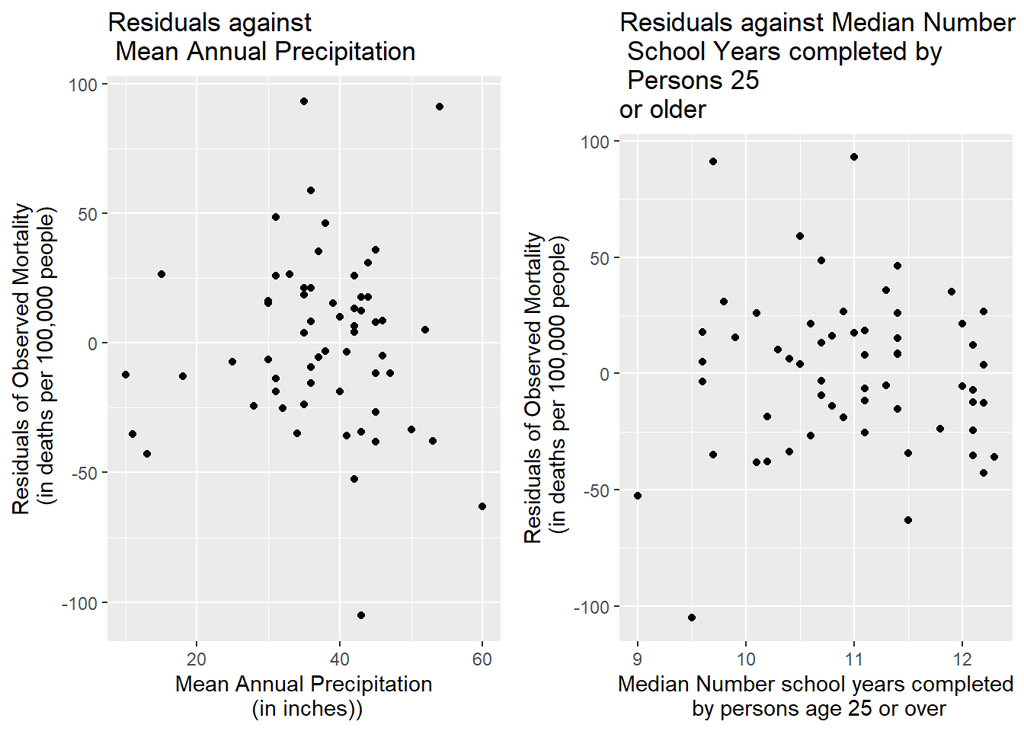

```r
grid.arrange(p.3, p.4, ncol=2)
```

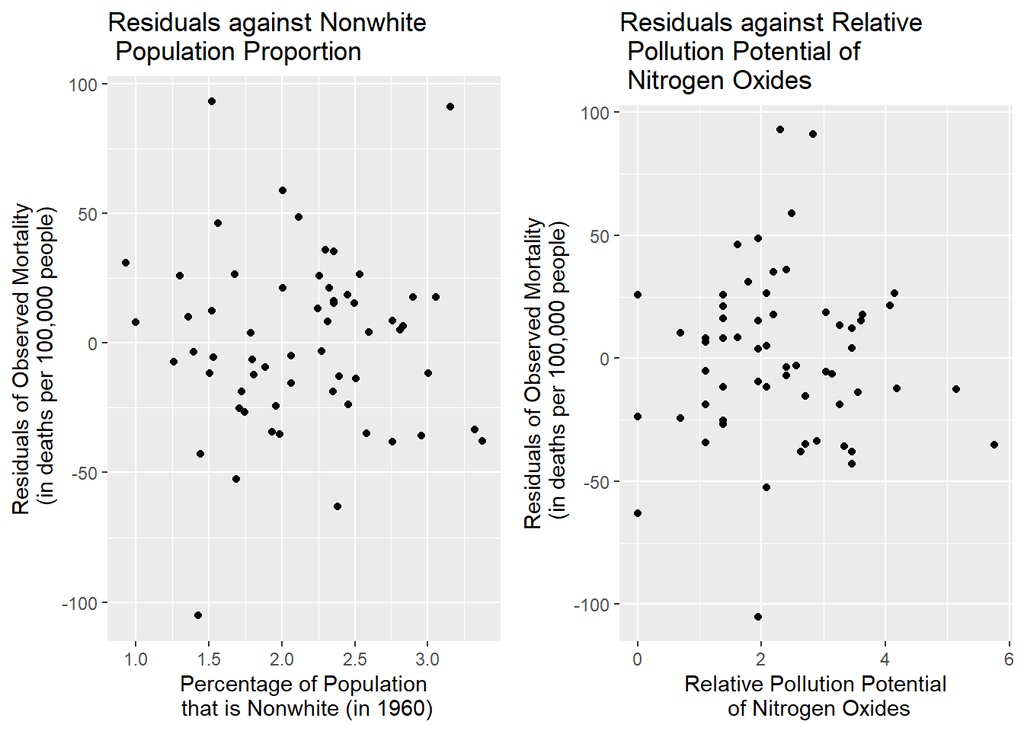

```r
grid.arrange(p.5, p.6, ncol=2)
```

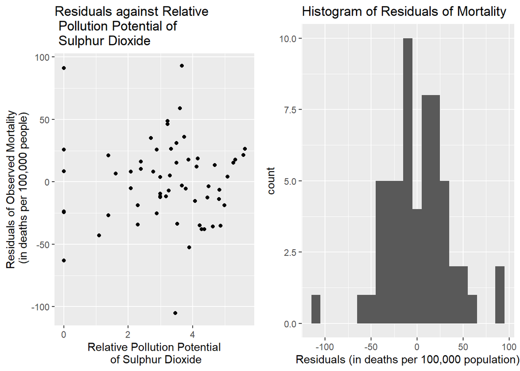

```r
grid.arrange(p.7, p.8, ncol=2)
```

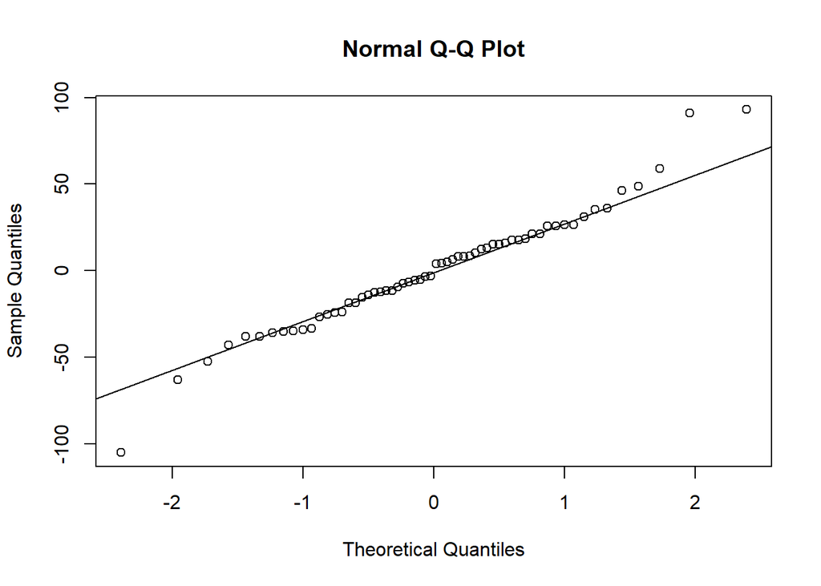

```r
#QQplot of residuals
qqnorm(new.model$residuals)
qqline(new.model$residuals)
```

### Model Selection Procedure

As a result of selecting the most appropriate model for our transformed data, we ran the default forward selection and backward elimination as well as the stepwise versions and all subsets regression. From these procedures we found that nonlinear predictors, SO2 and NONWHITE were not significant in predicting mortality.

```r
# Conduct all subsets regression on non-linearity term full model
Mortality.corr <- mutate(Mortality.corr, x_nonw=x,
                         x2_nonw=x2, x_so2=x1, x2_so2x=x2.1)
Mortality.corr.new <- Mortality.corr[,-c(4,7)]

selection <- leaps(x=Mortality.corr.new[,-1],
                   y=Mortality.corr.new[,1], method = 'Cp')
index <- order(selection$Cp, decreasing = FALSE)
index.values <- sort(selection$Cp, decreasing = FALSE)
best.models <- selection$which[index, ]
```

Best model has Predictors 1, 2, 5, 7 which is PRECIP, EDUC, x_nonw, x_so2 with Mallow’s $C_p$ of $4.3329$.

```r
# Forward Selection
xtable(step(lm(MORTALITY~1, data=Mortality.corr),
     ~PRECIP+EDUC+x+x2+POOR+NOX+x1+x2.1, direction = 'forward'))
```

```
## Start:  AIC=496.64
## MORTALITY ~ 1
##
##          Df Sum of Sq    RSS    AIC
## + x       1     83923 144350 471.14
## + EDUC    1     59603 168671 480.48
## + PRECIP  1     59256 169017 480.60
## + POOR    1     38370 189903 487.60
## + x1      1     37098 191176 488.00
## + NOX     1     19463 208810 493.29
## + x2      1     17836 210437 493.76
## <none>                228273 496.64
## + x2.1    1       155 228118 498.60
##
## Step:  AIC=471.14
## MORTALITY ~ x
##
##          Df Sum of Sq    RSS    AIC
## + EDUC    1     42716 101634 452.09
## + x1      1     30892 113459 458.69
## + PRECIP  1     25361 118990 461.55
## + x2      1     12660 131691 467.63
## + x2.1    1      9249 135102 469.17
## + NOX     1      7037 137313 470.14
## <none>                144350 471.14
## + POOR    1       755 143596 472.82
##
## Step:  AIC=452.09
## MORTALITY ~ x + EDUC
##
##          Df Sum of Sq    RSS    AIC
## + x1      1   16384.6  85249 443.54
## + NOX     1    8748.5  92885 448.69
## + x2.1    1    5066.2  96568 451.02
## + PRECIP  1    4787.0  96847 451.19
## + POOR    1    4379.8  97254 451.44
## <none>                101634 452.09
## + x2      1    3010.8  98623 452.28
##
## Step:  AIC=443.54
## MORTALITY ~ x + EDUC + x1
##
##          Df Sum of Sq   RSS    AIC
## + PRECIP  1   13284.5 71965 435.38
## + x2      1    4541.4 80708 442.25
## <none>                85249 443.54
## + POOR    1      89.7 85160 445.48
## + NOX     1      76.8 85173 445.49
## + x2.1    1      14.0 85235 445.53
##
## Step:  AIC=435.38
## MORTALITY ~ x + EDUC + x1 + PRECIP
##
##        Df Sum of Sq   RSS    AIC
## <none>              71965 435.38
## + NOX   1   2087.41 69877 435.61
## + x2    1   1118.71 70846 436.44
## + POOR  1    577.42 71387 436.89
## + x2.1  1    145.32 71819 437.25
```

|  | Estimate | Std. Error | t value | Pr(>\|t\|) |
| --- | --- | --- | --- | --- |
| (Intercept) | 1036.340837 | 89.5818233 | 11.568651 | 2.340193e-16 |
| x | 49.401151 | 8.6557061 | 5.707351 | 4.755085e-07 |
| EDUC | -15.215908 | 6.8818423 | -2.211022 | 3.121038e-02 |
| x1 | 14.947977 | 3.4278153 | 4.360788 | 5.734506e-05 |
| PRECIP | 1.899692 | 0.5961953 | 3.186358 | 2.375537e-03 |

```r
# Backward Selection
xtable(step(lm(MORTALITY~PRECIP+EDUC+x+x2+POOR+NOX+x1+x2.1, data=Mortality.corr),
     ~1, direction = 'backward'))
```

```
## Start:  AIC=439.58
## MORTALITY ~ PRECIP + EDUC + x + x2 + POOR + NOX + x1 + x2.1
##
##          Df Sum of Sq   RSS    AIC
## - x2.1    1      37.8 67588 437.61
## - NOX     1    1212.3 68763 438.64
## - x2      1    1261.6 68812 438.69
## - POOR    1    1877.9 69428 439.22
## - x1      1    2260.7 69811 439.55
## <none>                67550 439.58
## - EDUC    1    7973.2 75523 444.27
## - PRECIP  1   10874.4 78425 446.53
## - x       1   25145.1 92695 456.56
##
## Step:  AIC=437.61
## MORTALITY ~ PRECIP + EDUC + x + x2 + POOR + NOX + x1
##
##          Df Sum of Sq   RSS    AIC
## - x2      1    1239.7 68828 436.70
## - NOX     1    1600.2 69188 437.01
## - POOR    1    1857.6 69446 437.24
## <none>                67588 437.61
## - x1      1    2894.7 70483 438.13
## - EDUC    1    8258.3 75846 442.53
## - PRECIP  1   11211.7 78800 444.82
## - x       1   25840.2 93428 455.04
##
## Step:  AIC=436.7
## MORTALITY ~ PRECIP + EDUC + x + POOR + NOX + x1
##
##          Df Sum of Sq   RSS    AIC
## - POOR    1    1049.6 69877 435.61
## <none>                68828 436.70
## - NOX     1    2559.6 71387 436.89
## - x1      1    2646.3 71474 436.96
## - EDUC    1    8035.2 76863 441.33
## - PRECIP  1   16270.2 85098 447.43
## - x       1   25214.8 94043 453.43
##
## Step:  AIC=435.61
## MORTALITY ~ PRECIP + EDUC + x + NOX + x1
##
##          Df Sum of Sq   RSS    AIC
## - NOX     1    2087.4 71965 435.38
## <none>                69877 435.61
## - x1      1    4883.9 74761 437.66
## - EDUC    1    7050.7 76928 439.38
## - PRECIP  1   15295.2 85173 445.49
## - x       1   28331.7 98209 454.03
##
## Step:  AIC=435.38
## MORTALITY ~ PRECIP + EDUC + x + x1
##
##          Df Sum of Sq    RSS    AIC
## <none>                 71965 435.38
## - EDUC    1      6397  78361 438.48
## - PRECIP  1     13285  85249 443.54
## - x1      1     24882  96847 451.19
## - x       1     42621 114586 461.28
```

|  | Estimate | Std. Error | t value | Pr(>\|t\|) |
| --- | --- | --- | --- | --- |
| (Intercept) | 1036.340837 | 89.5818233 | 11.568651 | 2.340193e-16 |
| PRECIP | 1.899692 | 0.5961953 | 3.186358 | 2.375537e-03 |
| EDUC | -15.215908 | 6.8818423 | -2.211022 | 3.121038e-02 |
| x | 49.401151 | 8.6557061 | 5.707351 | 4.755085e-07 |
| x1 | 14.947977 | 3.4278153 | 4.360788 | 5.734506e-05 |

```r
# Forward Stepwise
xtable(step(lm(MORTALITY~1, data=Mortality.corr),
     ~PRECIP+EDUC+x+x2+POOR+NOX+x1+x2.1, direction = 'both'))
```

```
## Start:  AIC=496.64
## MORTALITY ~ 1
##
##          Df Sum of Sq    RSS    AIC
## + x       1     83923 144350 471.14
## + EDUC    1     59603 168671 480.48
## + PRECIP  1     59256 169017 480.60
## + POOR    1     38370 189903 487.60
## + x1      1     37098 191176 488.00
## + NOX     1     19463 208810 493.29
## + x2      1     17836 210437 493.76
## <none>                228273 496.64
## + x2.1    1       155 228118 498.60
##
## Step:  AIC=471.14
## MORTALITY ~ x
##
##          Df Sum of Sq    RSS    AIC
## + EDUC    1     42716 101634 452.09
## + x1      1     30892 113459 458.69
## + PRECIP  1     25361 118990 461.55
## + x2      1     12660 131691 467.63
## + x2.1    1      9249 135102 469.17
## + NOX     1      7037 137313 470.14
## <none>                144350 471.14
## + POOR    1       755 143596 472.82
## - x       1     83923 228273 496.64
##
## Step:  AIC=452.09
## MORTALITY ~ x + EDUC
##
##          Df Sum of Sq    RSS    AIC
## + x1      1     16385  85249 443.54
## + NOX     1      8748  92885 448.69
## + x2.1    1      5066  96568 451.02
## + PRECIP  1      4787  96847 451.19
## + POOR    1      4380  97254 451.44
## <none>                101634 452.09
## + x2      1      3011  98623 452.28
## - EDUC    1     42716 144350 471.14
```

[output cut: 14 more lines]

```
## - x       1     65315 150565 475.67
##
## Step:  AIC=435.38
## MORTALITY ~ x + EDUC + x1 + PRECIP
##
##          Df Sum of Sq    RSS    AIC
## <none>                 71965 435.38
## + NOX     1      2087  69877 435.61
## + x2      1      1119  70846 436.44
## + POOR    1       577  71387 436.89
## + x2.1    1       145  71819 437.25
## - EDUC    1      6397  78361 438.48
## - PRECIP  1     13285  85249 443.54
## - x1      1     24882  96847 451.19
## - x       1     42621 114586 461.28
```

|  | Estimate | Std. Error | t value | Pr(>\|t\|) |
| --- | --- | --- | --- | --- |
| (Intercept) | 1036.340837 | 89.5818233 | 11.568651 | 2.340193e-16 |
| x | 49.401151 | 8.6557061 | 5.707351 | 4.755085e-07 |
| EDUC | -15.215908 | 6.8818423 | -2.211022 | 3.121038e-02 |
| x1 | 14.947977 | 3.4278153 | 4.360788 | 5.734506e-05 |
| PRECIP | 1.899692 | 0.5961953 | 3.186358 | 2.375537e-03 |

```r
# Backward Stepwise
xtable(step(lm(MORTALITY~PRECIP+EDUC+x+x2+POOR+NOX+x1+x2.1, data=Mortality.corr),
     ~1, direction = 'both'))
```

```
## Start:  AIC=439.58
## MORTALITY ~ PRECIP + EDUC + x + x2 + POOR + NOX + x1 + x2.1
##
##          Df Sum of Sq   RSS    AIC
## - x2.1    1      37.8 67588 437.61
## - NOX     1    1212.3 68763 438.64
## - x2      1    1261.6 68812 438.69
## - POOR    1    1877.9 69428 439.22
## - x1      1    2260.7 69811 439.55
## <none>                67550 439.58
## - EDUC    1    7973.2 75523 444.27
## - PRECIP  1   10874.4 78425 446.53
## - x       1   25145.1 92695 456.56
##
## Step:  AIC=437.61
## MORTALITY ~ PRECIP + EDUC + x + x2 + POOR + NOX + x1
##
##          Df Sum of Sq   RSS    AIC
## - x2      1    1239.7 68828 436.70
## - NOX     1    1600.2 69188 437.01
## - POOR    1    1857.6 69446 437.24
## <none>                67588 437.61
## - x1      1    2894.7 70483 438.13
## - EDUC    1    8258.3 75846 442.53
## - PRECIP  1   11211.7 78800 444.82
## - x       1   25840.2 93428 455.04
##
## Step:  AIC=436.7
## MORTALITY ~ PRECIP + EDUC + x + POOR + NOX + x1
##
##          Df Sum of Sq   RSS    AIC
## - POOR    1    1049.6 69877 435.61
## <none>                68828 436.70
## - NOX     1    2559.6 71387 436.89
## - x1      1    2646.3 71474 436.96
## - EDUC    1    8035.2 76863 441.33
## - PRECIP  1   16270.2 85098 447.43
## - x       1   25214.8 94043 453.43
##
## Step:  AIC=435.61
## MORTALITY ~ PRECIP + EDUC + x + NOX + x1
##
##          Df Sum of Sq   RSS    AIC
## - NOX     1    2087.4 71965 435.38
## <none>                69877 435.61
## - x1      1    4883.9 74761 437.66
## - EDUC    1    7050.7 76928 439.38
## - PRECIP  1   15295.2 85173 445.49
## - x       1   28331.7 98209 454.03
##
## Step:  AIC=435.38
## MORTALITY ~ PRECIP + EDUC + x + x1
##
##          Df Sum of Sq    RSS    AIC
## <none>                 71965 435.38
## - EDUC    1      6397  78361 438.48
## - PRECIP  1     13285  85249 443.54
## - x1      1     24882  96847 451.19
## - x       1     42621 114586 461.28
```

|  | Estimate | Std. Error | t value | Pr(>\|t\|) |
| --- | --- | --- | --- | --- |
| (Intercept) | 1036.340837 | 89.5818233 | 11.568651 | 2.340193e-16 |
| PRECIP | 1.899692 | 0.5961953 | 3.186358 | 2.375537e-03 |
| EDUC | -15.215908 | 6.8818423 | -2.211022 | 3.121038e-02 |
| x | 49.401151 | 8.6557061 | 5.707351 | 4.755085e-07 |
| x1 | 14.947977 | 3.4278153 | 4.360788 | 5.734506e-05 |

```r
# partial R^2 calculation from adding NONWHITE quadratic term to "Best" model
best.reduced.NON <- lm(MORTALITY~PRECIP+EDUC+x+x1, data=Mortality.corr)
best.full.NON <- lm(MORTALITY~PRECIP+EDUC+x+x2+x1, data=Mortality.corr)

SSE.red <- ((anova(best.reduced.NON))[5,2])
SSE.full <- ((anova(best.full.NON))[6,2])
partial.R2.NON <- (SSE.red-SSE.full)/SSE.full
```

There is a $\Large 1.60\%$ reduction in residual sum of squares when adding a quadratic term for data on the population percentage in 1960 that is nonwhite to a model containing the linear term for data on said population percentage, the linear term for data on SO2 pollution potential, the mean annual precipitation, and the median number of school years completed by persons aged $25$ or older.

```r
# partial R^2 calculation from adding SO2 quadratic term to the "Best" model
best.reduced.SO2 <- lm(MORTALITY~PRECIP+EDUC+x+x1, data=Mortality.corr)
best.full.SO2 <- lm(MORTALITY~PRECIP+EDUC+x+x2.1+x1, data=Mortality.corr)

SSE.red <- ((anova(best.reduced.SO2))[5,2])
SSE.full <- ((anova(best.full.SO2))[6,2])
partial.R2.SO2 <- (SSE.red-SSE.full)/SSE.full
```

There is a $\Large 0.20\%$ reduction in residual sum of squares when adding a quadratic term for data on the relative pollution potential of sulphur dioxide to a model containing the linear term for data on said relative pollution potential, the mean annual precipitation, and the median number of school years completed by persons aged $25$ or older.

# R Appendix

```r
# ref.label=knitr::all_labels(),echo=TRUE,eval=FALSE

# code to put everything at the appendix. but still need echo=F in each code
# block tho.
```

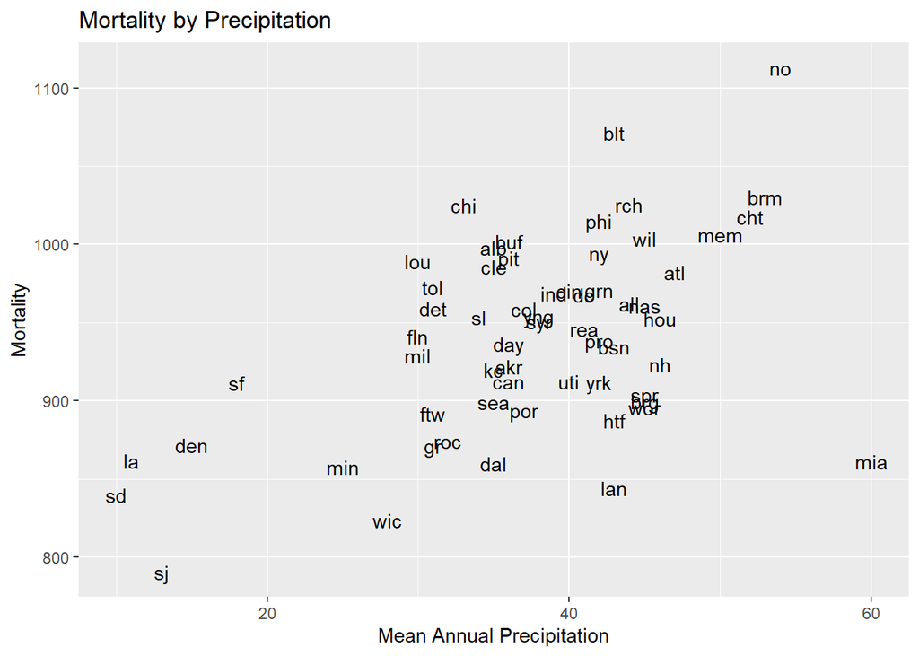

```r
ggplot(data=Mortality.trans[,-8], aes(x=Mortality.trans$PRECIP,
                          y=Mortality.trans$MORTALITY, label=Mortality.trans[,8])) +
  geom_text() +
  xlab(paste("Mean Annual Precipitation")) +
  ylab("Mortality") +
  ggtitle("Mortality by Precipitation")
```

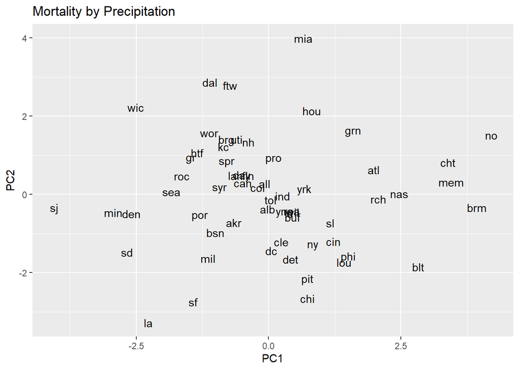

```r
pca <- prcomp(Mortality.trans[,-8], scale = TRUE)

pca.data <- data.frame(pca$x[,1], pca$x[,2])
colnames(pca.data) <- c("x", "y")

ggplot(data=pca.data, aes(x=x,
                          y=y, label=Mortality.trans[,8])) +
  geom_text() +
  xlab(paste("PC1")) +
  ylab("PC2") +
  ggtitle("Mortality by Precipitation")
```

```r
tsne.data <- tsne::tsne(Mortality.trans[,-8])
```

```
## sigma summary: Min. : 0.691750423436813 |1st Qu. : 0.779183565942645 |Median : 0.810269067113754 |Mean : 0.82277966480536 |3rd Qu. : 0.866712224667101 |Max. : 1.02362337588377 |
```

[output not shown]

[output not shown]

[output not shown]

[output not shown]

[output not shown]

[output not shown]

[output not shown]

[output not shown]

[output not shown]

[output not shown]

```r
plot.tsne.data <- data.frame(tsne.data)
plot.tsne.data <- data.frame(Mortality.trans$CITY, tsne.data); head(plot.tsne.data)
```

|  | Mortality.trans.CITY | X1 | X2 |
| --- | --- | --- | --- |
| 1 | akr | 37.13002 | -39.84483 |
| 2 | alb | -213.06885 | 463.23880 |
| 3 | all | -183.69845 | 213.51339 |
| 4 | atl | 70.50319 | -451.78121 |
| 5 | blt | 361.77030 | -172.92691 |
| 6 | brm | 53.35695 | -573.16106 |

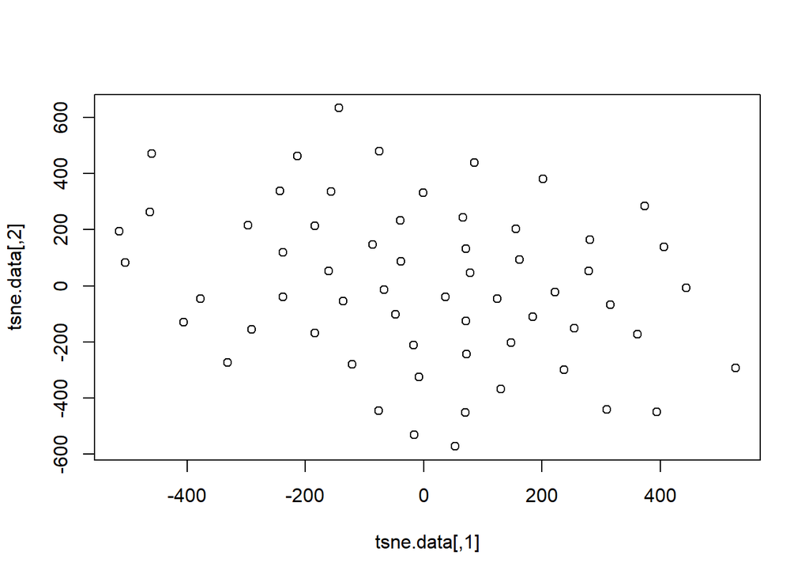

```r
plot(tsne.data)
```

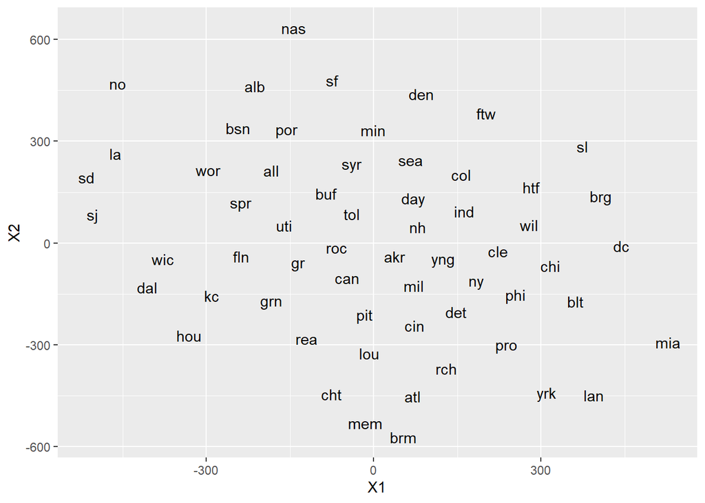

```r
ggplot(plot.tsne.data, aes(x=X1, y=X2,
                           label=plot.tsne.data$Mortality.trans.CITY)) +
  geom_text()
```